# IODS Course Project

Justin Box

# About the Project

*This is Intro to Open Data Science. A course for everyone and a course for anywhere. The course runs for 7 weeks (Tue. 16-18:00) and consists of multiple on-line projects and assignments.*

[My Repository](https://github.com/justinrbox/IODS-project)

# IODS Week 2

*This weeks assignments included data wrangling and analysis!*

## Brief Description of Data

*The data in this table is student responses to questions regarding 3 types of learning apporaches (Deep,Surface, and Strategic). The dataset also includes personal characteristics like age, gender.* *Students were asked several questions (scale 1-5) regarding each type of learning. The average of these responses is presented in the table.*

### Summary of Results

*For this data set, 66% of respondents were female and 34% were male. Their ages ranged from 17-55 (mean 25.5) years old. Points ranged from 7-33 (mean 22.7) The average scale rating of “attitude”“,”deep“,”stra“, and”surf" was 3.1, 3.6, 3.1, and 2.7 respectively*

*Code*

### Regression Models

*Code*

##### fit a linear model

points_v_attitude <- lm(points ~ attitude, data = students2014)

#### Interpretation

my_model2 <- lm(points ~ attitude + stra, data = students2014)

# IODS Week 3

## The Data

*This data evaluates student achievement in secondary education of two Portuguese schools. The data attributes include student grades, demographic, social and school related features and it was collected by using school reports and questionnaires. Two datasets are provided regarding the performance in two distinct subjects: Mathematics (mat) and Portuguese language (por).*

*For this analysis, the two data sets were combined and only those cases with the same student’s repsonse in BOTH data sets were included.*

## Description of Variables

For full description of the variables [Click Here](https://archive.ics.uci.edu/ml/datasets/Student+Performance)

alc_use is the average of ‘Dalc’ and ‘Walc’ high_use is TRUE if ‘alc_use’ is higher than 2 and FALSE otherwise

*The focus of this analysis is on the relationships between high/low alcohol consumption and selected other variables in the data*

### My Hypotheses

*1) Parental education affects alcohol use*

*2) Study time affects alcohol use*

*3) Access to internet affects alcohol use*

*4) Address affects alcohol use*

## Analysis

alc <- read.csv(file = “alc.csv”, header=TRUE, sep=“,”)

### Looking at Various Plots

```
## Observations: 382
## Variables: 36
## $ X          <int> 1, 2, 3, 4, 5, 6, 7, 8, 9, 10, 11, 12, 13, 14, 15, ...
## $ school     <fct> GP, GP, GP, GP, GP, GP, GP, GP, GP, GP, GP, GP, GP,...
## $ sex        <fct> F, F, F, F, F, M, M, F, M, M, F, F, M, M, M, F, F, ...
## $ age        <int> 18, 17, 15, 15, 16, 16, 16, 17, 15, 15, 15, 15, 15,...
## $ address    <fct> U, U, U, U, U, U, U, U, U, U, U, U, U, U, U, U, U, ...
## $ famsize    <fct> GT3, GT3, LE3, GT3, GT3, LE3, LE3, GT3, LE3, GT3, G...
## $ Pstatus    <fct> A, T, T, T, T, T, T, A, A, T, T, T, T, T, A, T, T, ...
## $ Medu       <int> 4, 1, 1, 4, 3, 4, 2, 4, 3, 3, 4, 2, 4, 4, 2, 4, 4, ...
## $ Fedu       <int> 4, 1, 1, 2, 3, 3, 2, 4, 2, 4, 4, 1, 4, 3, 2, 4, 4, ...
## $ Mjob       <fct> at_home, at_home, at_home, health, other, services,...
## $ Fjob       <fct> teacher, other, other, services, other, other, othe...
## $ reason     <fct> course, course, other, home, home, reputation, home...
## $ nursery    <fct> yes, no, yes, yes, yes, yes, yes, yes, yes, yes, ye...
```

[output cut: 23 more lines]

```
## Observations: 13,752
## Variables: 2
## $ key   <chr> "X", "X", "X", "X", "X", "X", "X", "X", "X", "X", "X", "...
## $ value <chr> "1", "2", "3", "4", "5", "6", "7", "8", "9", "10", "11",...
```

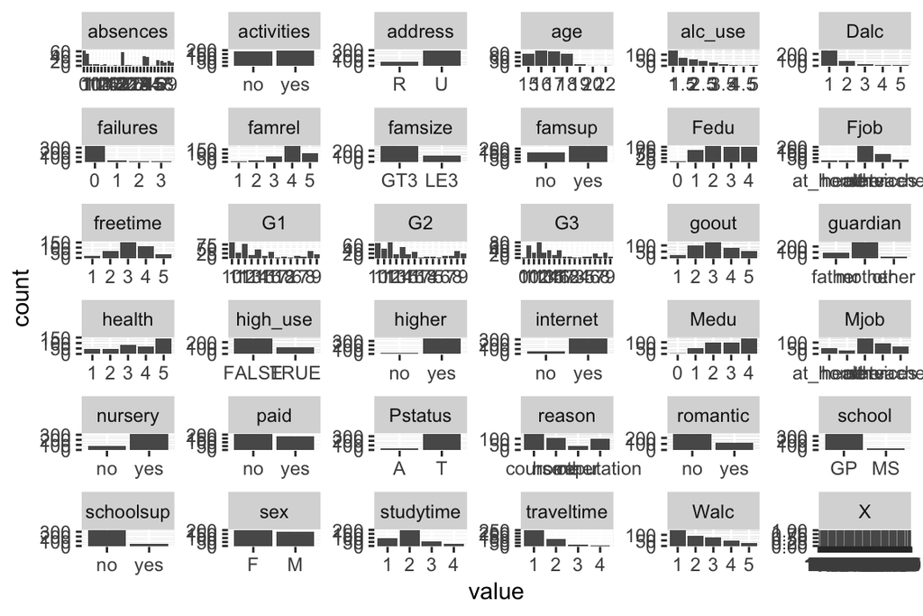

```
## # A tibble: 4 x 4
## # Groups:   sex [?]
##   sex   high_use count mean_grade
##   <fct> <lgl>    <int>      <dbl>
## 1 F     FALSE      156       11.4
## 2 F     TRUE        42       11.7
## 3 M     FALSE      112       12.2
## 4 M     TRUE        72       10.3
```

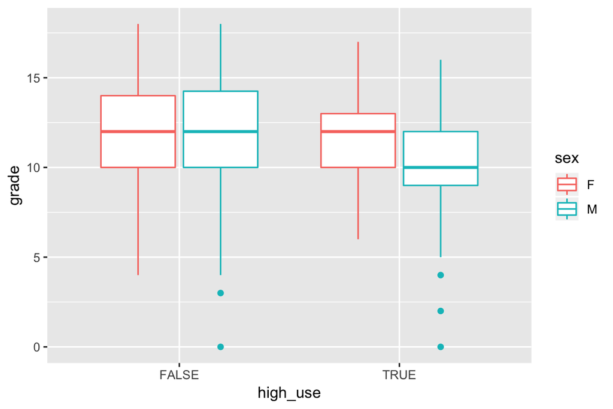

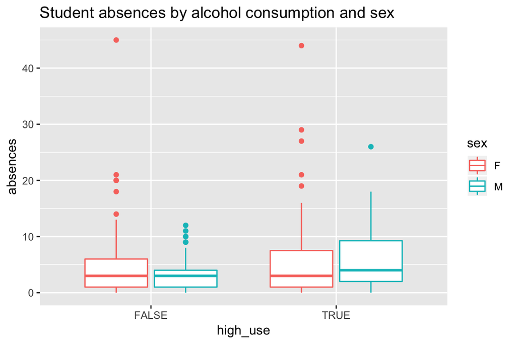

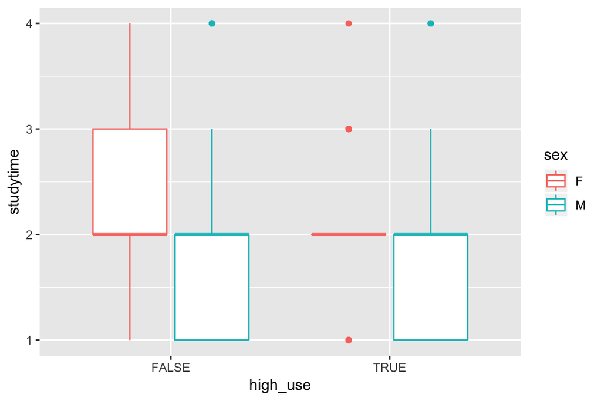

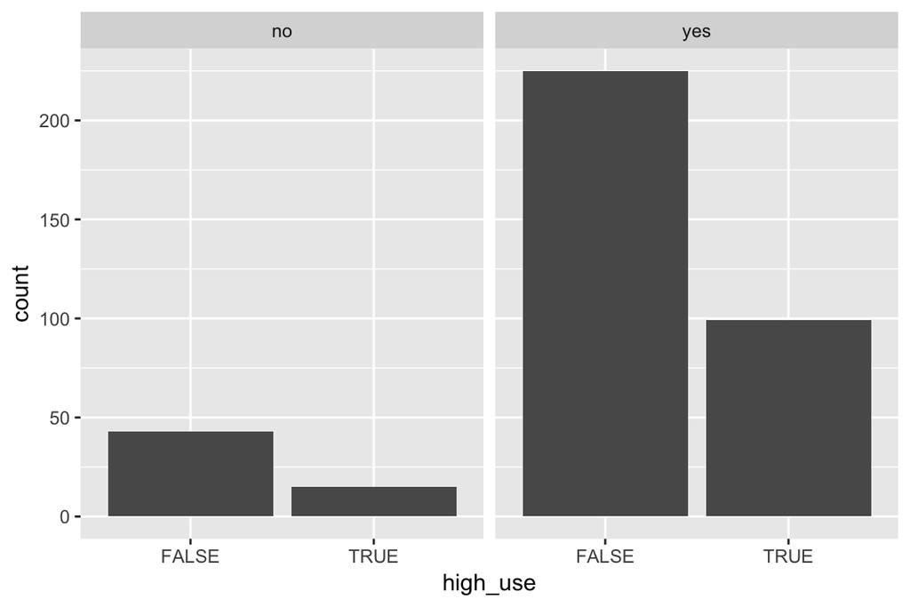

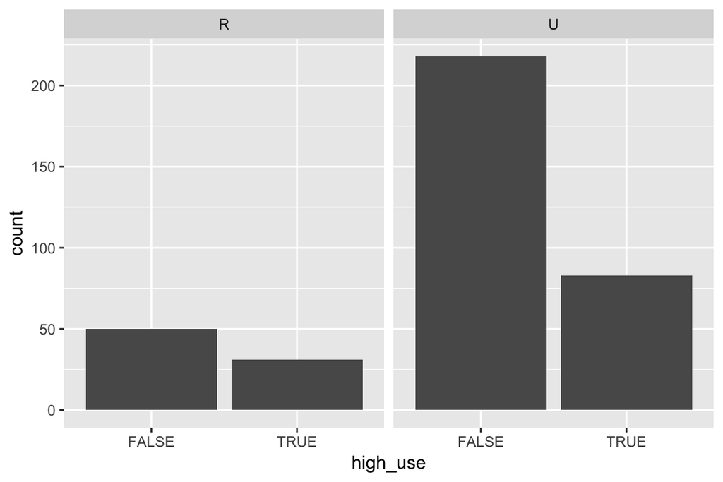

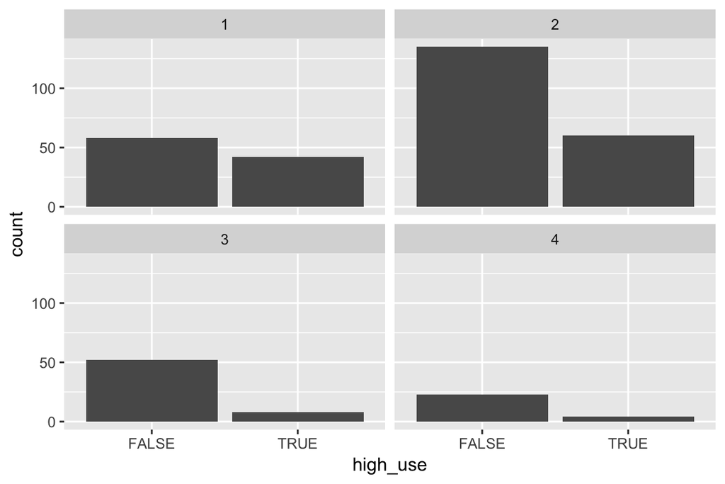

## Including Plots

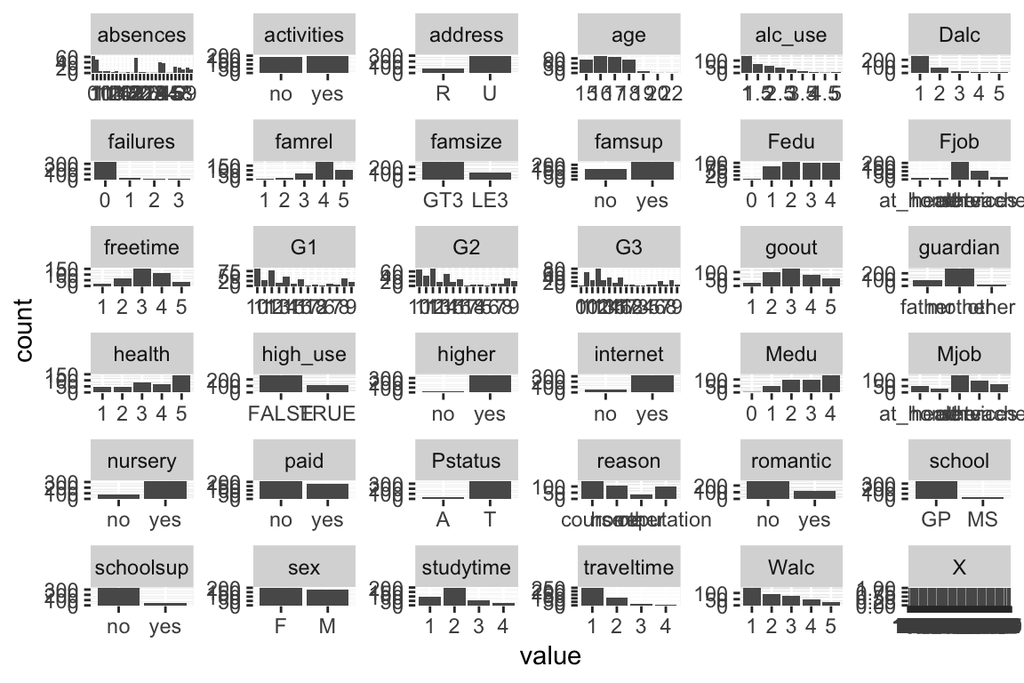

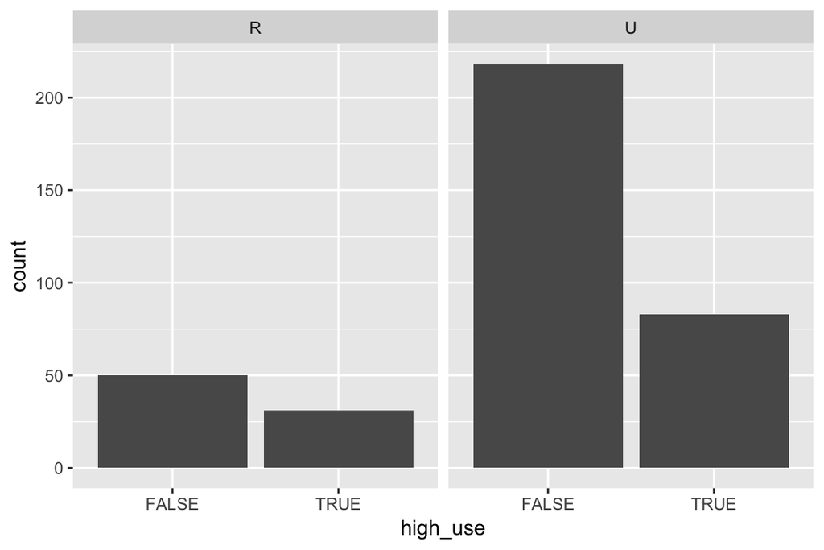

Analysis: there appears to be a greater proportion of “high use” individuals who live in rural areas compared to urban.

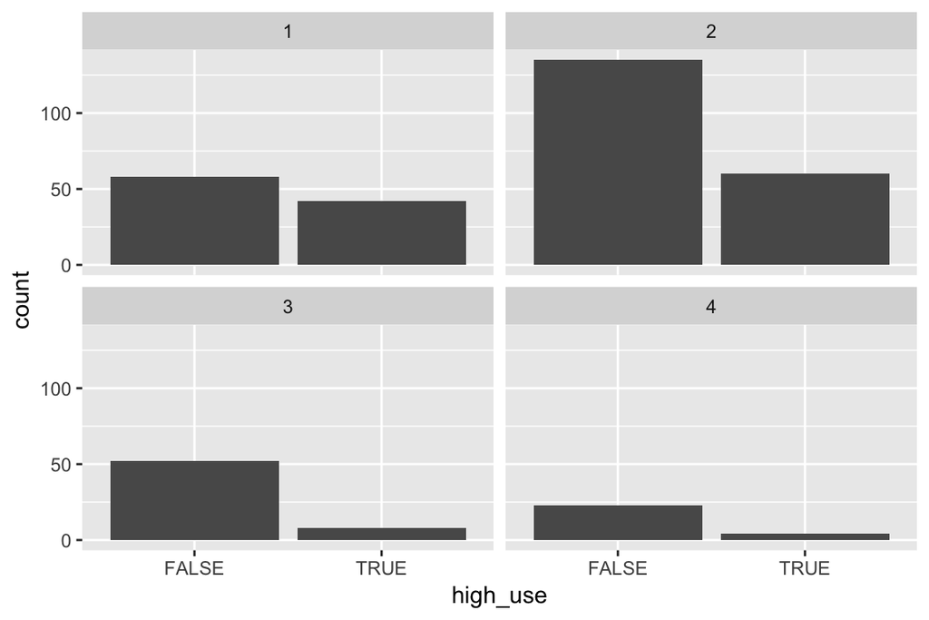

Analysis: there appears to be a greater proportion of “high use” individuals who studied less than 2 hours per week

## Logistic Regression

m <- glm(high_use ~ address + absences + studytime + failures, data = alc, family = “binomial”)

## Summary of the Model

```
##
## Call:
## glm(formula = high_use ~ address + absences + studytime + failures,
##     family = "binomial", data = alc)
##
## Deviance Residuals:
##     Min       1Q   Median       3Q      Max
## -2.3106  -0.8274  -0.6498   1.1066   2.2127
##
## Coefficients:
##             Estimate Std. Error z value Pr(>|z|)
## (Intercept)  0.03894    0.42264   0.092 0.926596
## addressU    -0.49810    0.27809  -1.791 0.073268 .
## absences     0.07883    0.02288   3.446 0.000569 ***
## studytime   -0.49431    0.15835  -3.122 0.001798 **
## failures     0.35312    0.19100   1.849 0.064487 .
## ---
## Signif. codes:  0 '***' 0.001 '**' 0.01 '*' 0.05 '.' 0.1 ' ' 1
##
## (Dispersion parameter for binomial family taken to be 1)
##
##     Null deviance: 465.68  on 381  degrees of freedom
## Residual deviance: 426.83  on 377  degrees of freedom
## AIC: 436.83
##
## Number of Fisher Scoring iterations: 4
```

### Coefficients of the Model

```
##                    OR     2.5 %    97.5 %
## (Intercept) 1.0397050 0.4536726 2.3898611
## addressU    0.6076839 0.3532793 1.0542771
## absences    1.0820164 1.0367785 1.1342085
## studytime   0.6099923 0.4431742 0.8256399
## failures    1.4235086 0.9792692 2.0818432
```

An odds ratio (OR) is a measure of association between an exposure and an outcome. The OR represents the odds that an outcome will occur given a particular exposure, compared to the odds of the outcome occurring in the absence of that exposure.

## Cross Tabulation

```
##         prediction
## high_use FALSE TRUE
##    FALSE   253   15
##    TRUE     89   25
```

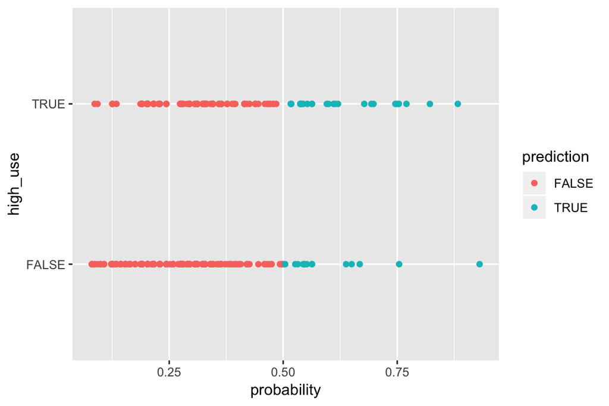

```
##         prediction
## high_use      FALSE       TRUE        Sum
##    FALSE 0.66230366 0.03926702 0.70157068
##    TRUE  0.23298429 0.06544503 0.29842932
##    Sum   0.89528796 0.10471204 1.00000000
```

## Inaccurately Classified Individuals

```
## [1] 0.2722513
```

The training error rate here is 27.2%.

## Bonus: 10-Fold Cross Validation

```
## [1] 0.2931937
```